# AAPL---Random Walk, ARMA, ARIMA, ARCH, GARH

### We could still see the autocorrelation in squared residuals. Let's fit a GARCH model and see how it does.there are some garch model

Now we can fit the arch model using the best fit arima model parameters

```python
p_ = order[0]
o_ = order[1]
q_ = order[2]

# Using student T distribution usually provides better fit
am = arch_model(model.resid, p=p_, o=o_, q=q_, dist='StudentsT')
res = am.fit(update_freq=5, disp='off')
print(res.summary())
```

```
                        Constant Mean - GARCH Model Results
====================================================================================
Dep. Variable:                         None   R-squared:                      -0.003
Mean Model:                   Constant Mean   Adj. R-squared:                 -0.003
Vol Model:                            GARCH   Log-Likelihood:                3432.86
Distribution:      Standardized Student's t   AIC:                          -6843.73
Method:                  Maximum Likelihood   BIC:                          -6787.22
                                              No. Observations:                 1258
Date:                      Sat, Sep 26 2020   Df Residuals:                     1247
Time:                              00:51:16   Df Model:                           11
                                 Mean Model
============================================================================
                 coef    std err          t      P>|t|      95.0% Conf. Int.
----------------------------------------------------------------------------
mu         1.7403e-03  2.934e-04      5.932  2.994e-09 [1.165e-03,2.315e-03]
                              Volatility Model
============================================================================
                 coef    std err          t      P>|t|      95.0% Conf. Int.
----------------------------------------------------------------------------
omega      1.3209e-04  3.332e-05      3.964  7.357e-05 [6.679e-05,1.974e-04]
alpha[1]       0.6466      0.211      3.059  2.222e-03     [  0.232,  1.061]
alpha[2]       0.0262      0.334  7.842e-02      0.937     [ -0.629,  0.681]
alpha[3]       0.0262      0.205      0.128      0.898     [ -0.376,  0.428]
alpha[4]       0.0262      0.581  4.509e-02      0.964     [ -1.113,  1.165]
beta[1]        0.0917      0.685      0.134      0.894     [ -1.251,  1.435]
beta[2]        0.0917      0.440      0.209      0.835     [ -0.770,  0.953]
beta[3]        0.0917      0.414      0.221      0.825     [ -0.720,  0.903]
beta[4]        0.0917      0.171      0.535      0.593     [ -0.244,  0.427]
                              Distribution
========================================================================
                 coef    std err          t      P>|t|  95.0% Conf. Int.
------------------------------------------------------------------------
nu            17.3633      0.996     17.437  4.298e-68 [ 15.412, 19.315]
========================================================================

Covariance estimator: robust
WARNING: The optimizer did not indicate successful convergence. The message was Positive directional derivative for linesearch.
See convergence_flag.
```

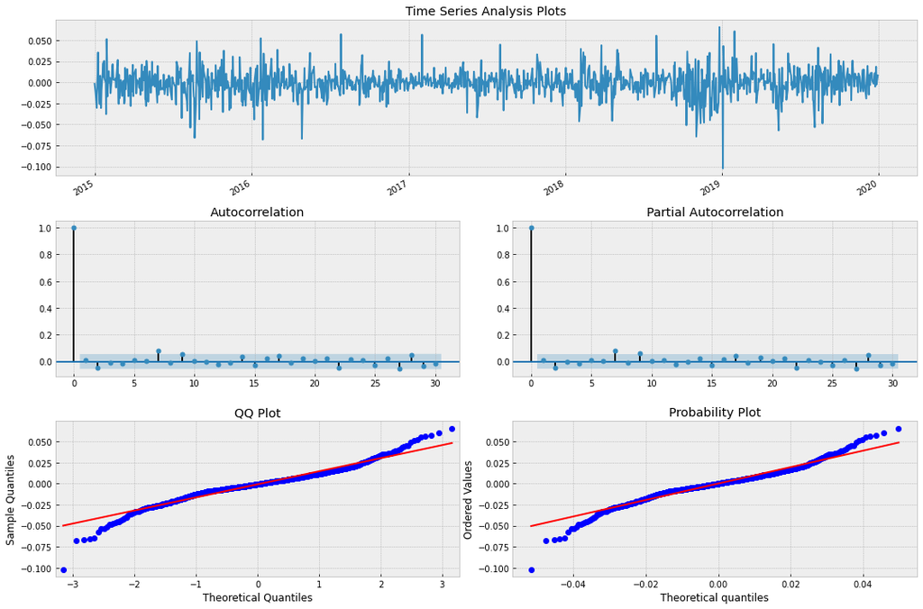

```python
tsplot(res.resid, lags=30)
```

```python
from statsmodels.stats.stattools import jarque_bera

score, pvalue, _, _ = jarque_bera(res.resid)

if pvalue < 0.10:
    print('We have reason to suspect the residuals are not normally distributed.')
else:
    print('The residuals seem normally distributed.')
```

```
We have reason to suspect the residuals are not normally distributed.
```

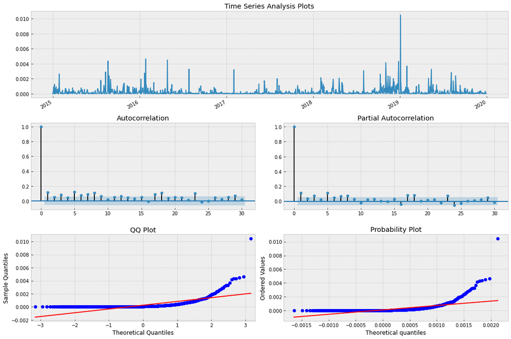

```python
tsplot(res.resid**2, lags=30)
```

### There are also some obvious autocorelation of the residuals and also it did not pass the normality test. So this model could not fit well.